# Effects of sediment on the mortality of adult corals

Lillian J. Tuttle

9/25/2020

These datasets contain information from multiple articles (**Ref_name**) and studies/experiments (**Ref**) within those articles about the effects of DEPOSITED & SUSPENDED sediment on the **total colony mortality** of adult corals, quantified as the percent of complete colony mortality within an experimental group. I would like to explore the dose-response relationship between sediment ‘dose’ and the effect size, estimated here as the log risk/rate ratio (**logRR**) or the log odds ratio (**logOR**):

Each study/experiment (Ref) may contain multiple sets of controls and treatments (due to using multiple species or sediment types, for instance). Thus, I have added two categorical vectors, ‘**Comparison**’ and ‘Control’, which group each set of control-treatment comparisons into a unique two-letter code, within which is one control (Control==“1”) and at least one treatment (Control==“0”). **Therefore, ‘Comparison’ is nested within ‘Ref’, which is further nested within ‘Ref_name’.**

# I. Deposited Sediment

## A. Plots

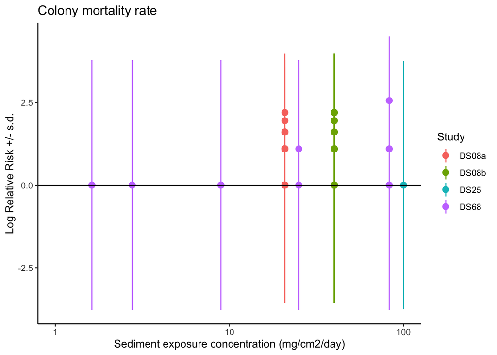

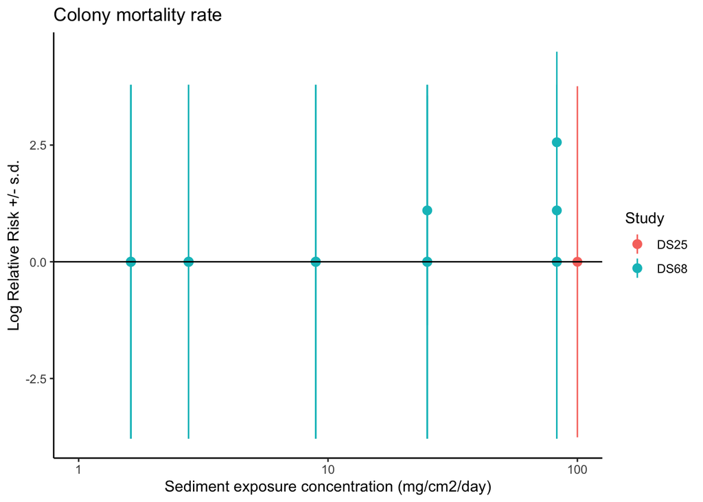

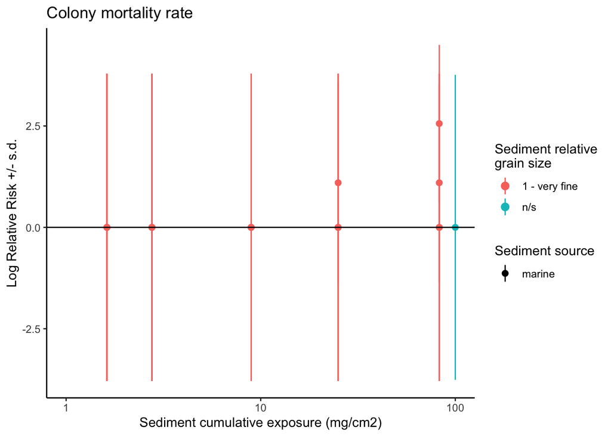

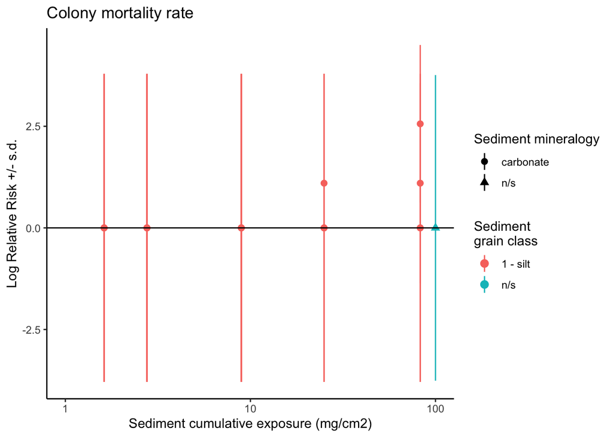

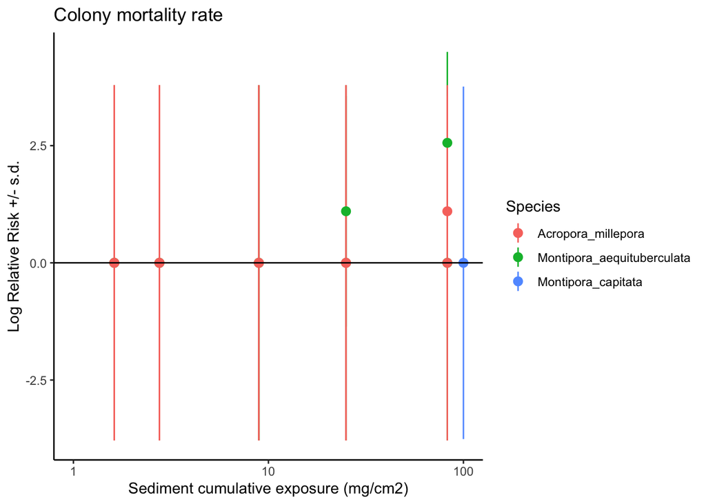

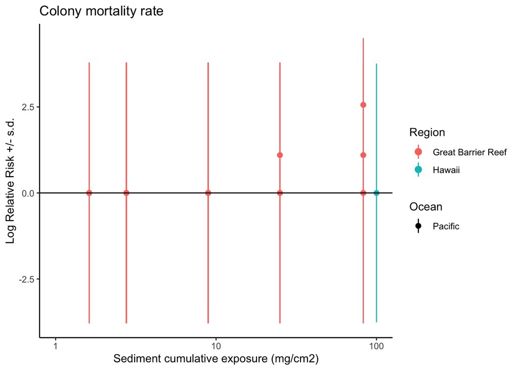

## B. Linear and Non-Linear Models

The following set of functions model fixed and random (nested) effects WITHOUT accounting for within-comparison (or within-study) correlations. The output for each is a univariate, random-effects meta-regression.

## C. Model Comparison and Summary

And now to compare relative fit of linear models…

```
##                       df      AIC
## mod_DS_totalmort1b     2 71.55120
## mod_ES_DS_totalmort2b  3 73.55120
## mod_DS_totalmort3b     2 65.37455
```

And now to evaluate residuals of models…

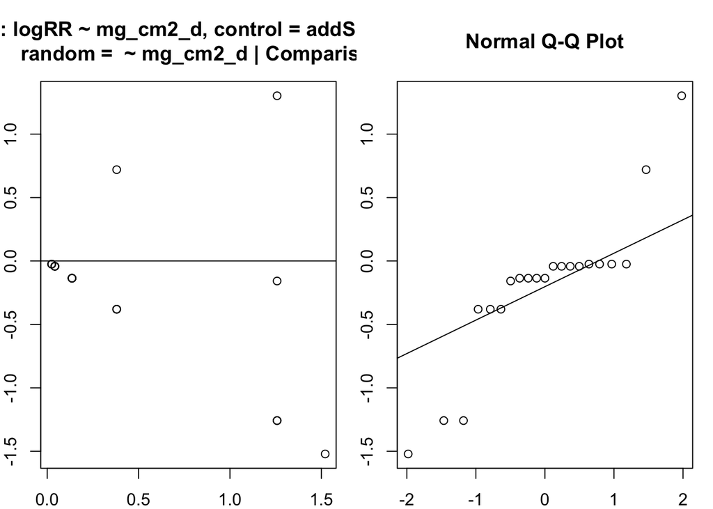

Patterns: 1. Looks ok despite sparse data.

## D. Best-Fit Model Summary

### MG/CM<sup>2</sup>/DAY IS PREDICTOR

Now I will predict the effect size along the exposure range and plot with confidence intervals.

```
## Call:  mixmeta(formula = logRR ~ 0 + Sed_level_standardized, data = ES_DS_totalmort_b2,
##     random = ~0 + Sed_level_standardized | Comparison, method = "ml",
##     control = list(addSlist = addS_ES_DS_totalmort_b))
##
## Univariate extended random-effects meta-regression
## Dimension: 1
## Estimation method: ML
##
## Fixed-effects coefficients
##                         Estimate  Std. Error       z  Pr(>|z|)  95%ci.lb
## Sed_level_standardized    0.0152      0.0068  2.2393    0.0251    0.0019
##                         95%ci.ub
## Sed_level_standardized    0.0285  *
## ---
## Signif. codes:  0 '***' 0.001 '**' 0.01 '*' 0.05 '.' 0.1 ' ' 1
##
## Random-effects (co)variance components
##  Formula: ~0 + Sed_level_standardized | Comparison
##  Structure: General positive-definite
##   Std. Dev
##     0.0007
##
## Univariate Cochran Q-test for residual heterogeneity:
## Q = 4.1606 (df = 20), p-value = 0.9999
## I-square statistic = 0.0%
##
## 21 units, 1 outcome, 21 observations, 1 fixed and 1 random-effects parameters
##   logLik       AIC       BIC
## -30.6873   65.3745   67.4636
```

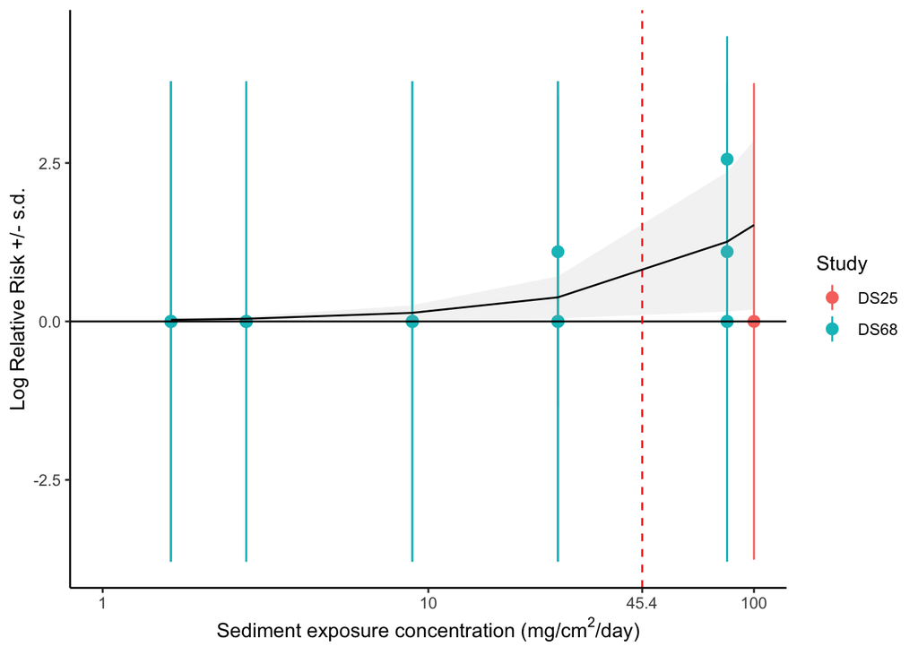

# II. Suspended Sediment

## A. Plots

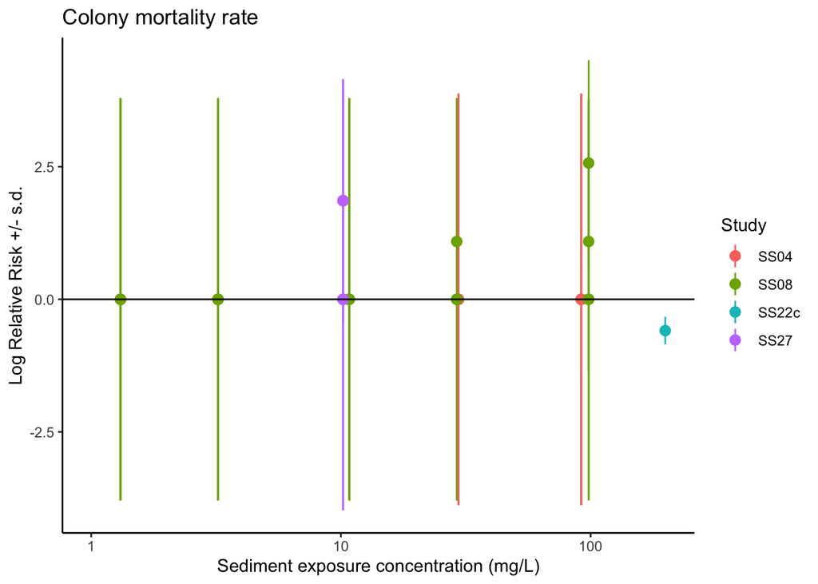

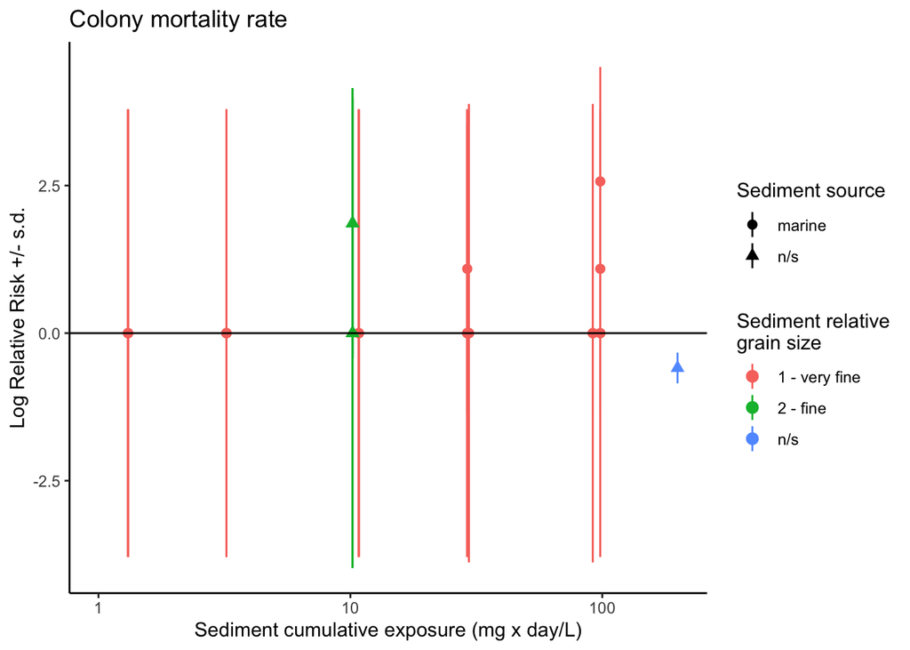

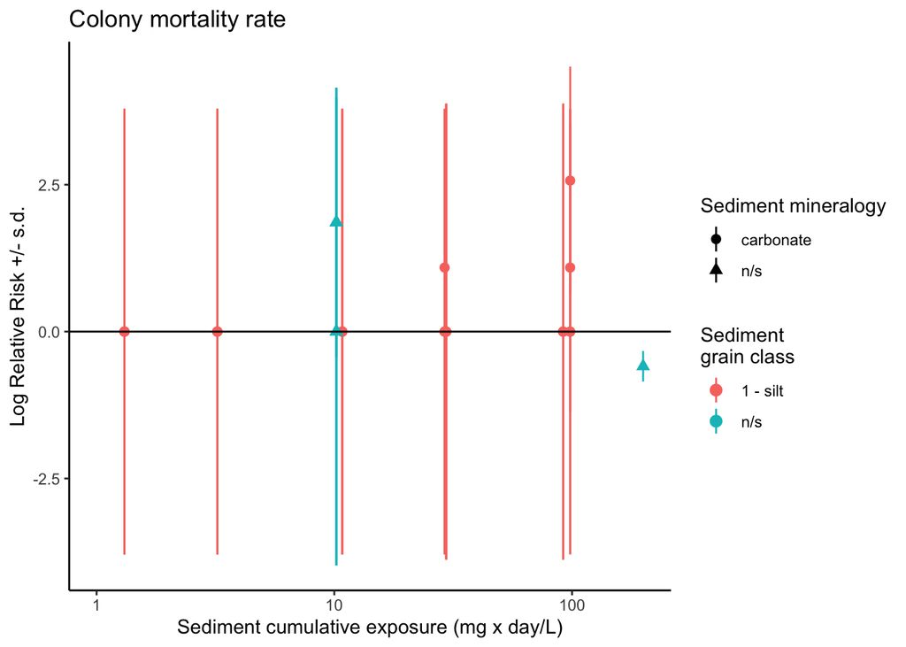

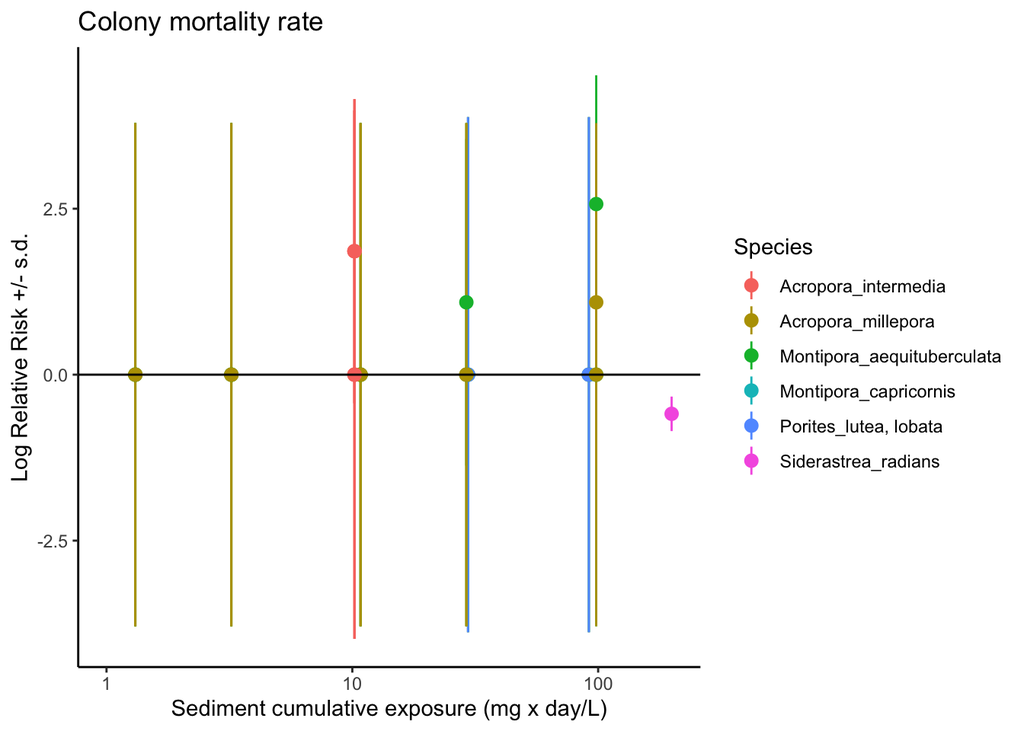

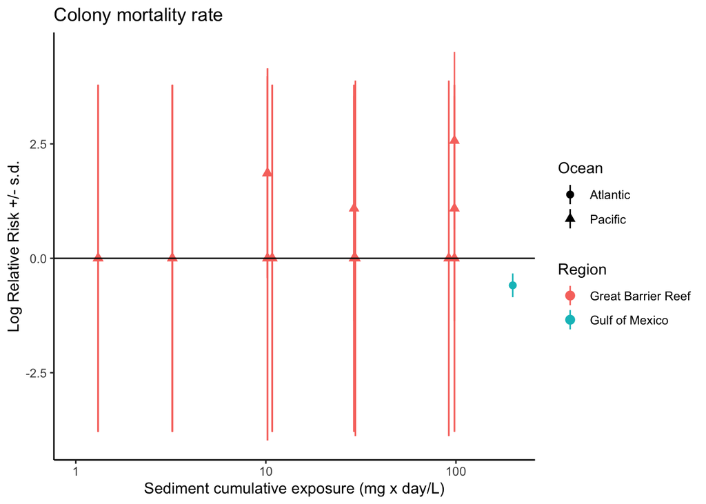

There does not appear to be a relationship between sediment exposure and effect size. Also, there does not appear to be strong effects of phylogeny (genus) or geography (ocean and region). Sediment type (source, origin, grain size) is yet to be analyzed.

## B. Model Fitting

The following set of functions model fixed and random (nested) effects WITHOUT accounting for within-comparison (or within-study) correlations. The output for each is a univariate, random-effects meta-regression.

## C. Model Comparison and Summary

And now to compare relative fit of linear models…

```
##                       df      AIC
## mod_ES_SS_totalmort1b  2 113.0921
## mod_ES_SS_totalmort2b  3 115.0921
```

And now to evaluate residuals of models…

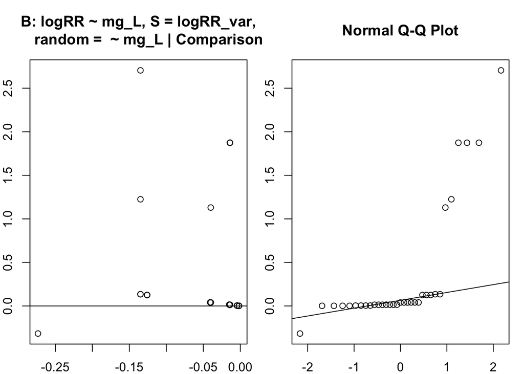

## D. Best-Fit Model Summary

Now I will predict the effect size along the exposure range and plot with confidence intervals.

```
## Call:  mixmeta(formula = logRR ~ 0 + Sed_level_standardized, S = logRR_var,
##     data = ES_SS_totalmort2, random = ~0 + Sed_level_standardized |
##         Comparison, method = "ml")
##
## Univariate extended random-effects meta-regression
## Dimension: 1
## Estimation method: ML
##
## Fixed-effects coefficients
##                         Estimate  Std. Error        z  Pr(>|z|)  95%ci.lb
## Sed_level_standardized   -0.0014      0.0024  -0.5745    0.5656   -0.0061
##                         95%ci.ub
## Sed_level_standardized    0.0033
## ---
## Signif. codes:  0 '***' 0.001 '**' 0.01 '*' 0.05 '.' 0.1 ' ' 1
##
## Random-effects (co)variance components
##  Formula: ~0 + Sed_level_standardized | Comparison
##  Structure: General positive-definite
##   Std. Dev
##     0.0000
##
## Univariate Cochran Q-test for residual heterogeneity:
## Q = 9.9115 (df = 32), p-value = 0.9999
## I-square statistic = 0.0%
##
## 33 units, 1 outcome, 33 observations, 1 fixed and 1 random-effects parameters
##   logLik       AIC       BIC
## -54.5461  113.0921  116.0851
```

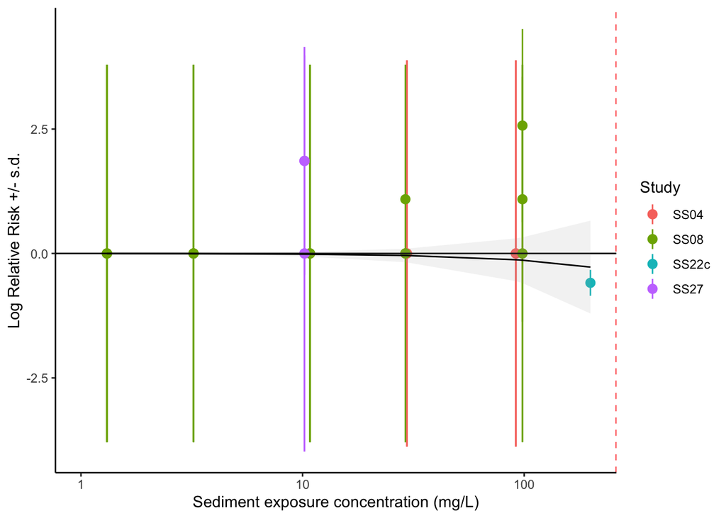